# COSC-523: Lab 04

**Daniel Carter**

[Notebook Link](https://colab.research.google.com/drive/1yHErN5bKVDpVM13g6sY9idYyd8_5uSM5?usp=sharing)

## Getting Started

Follow the instructions below to copy this notebook and to perform some initial setup.

1. Copy this notebook by selecting `File > Save a copy in Drive`.
2. A new window should open for the copied notebook. Move the new notebook to your course folder in Google Drive by selecting `File > Move` and then selecting the desired folder.
3. Update the name of the notebook by removing "Copy of" and replacing "Username" with your actual username.
4. Update the first cell in the notebook by specifying your course number (423 or 523) and by replacing "**Student Name**" with your actual name.
5. Do not edit the line that says `PLACEHOLDER_FOR_NOTEBOOK_LINK`. This will be used by the [Notebook Renderer](https://colab.research.google.com/drive/1CJTipys46ldZxJFwnt7XbdjQUfkmoXeU?usp=sharing) tool to insert a link to your Colab notebook.
6. Enable link sharing for your notebook.

# Part 1A: Understanding the Fundamentals of Haar Cascade Object Detection

Instructions: Answer the following questions to understand the basics of Haar Cascade Object Detection:

- What is a Haar Cascade? Explain what a Haar Cascade classifier is and how it is used for object detection.
- How does the Haar feature work? Discuss how Haar features (such as edge, line, and center-surround features) are used to detect objects.
- What is the process of training a Haar Cascade? Describe the steps involved in training a Haar Cascade classifier.
- What role does the integral image play in Haar Cascade detection? Explain how the integral image speeds up the feature calculation during object detection.
- What are false positives and false negatives in object detection, and how do Haar Cascades handle them?

```python
# Answer in comments
```

- What is a Haar Cascade? Explain what a Haar Cascade classifier is and how it is used for object detection.
  - Haat Cascade is one of the best non-deep learning object detection model algorithms out there. It works by using edge or line detection features.
  - A Haar Cascade classifier is a cascade of Viola-Jones classifiers. It works by using the classifiers in a cascading method where only the first classifier trains on all examples while the remaining classifiers train on the positive and negative examples that were misclassified in the previous classifier.
- How does the Haar feature work? Discuss how Haar features (such as edge, line, and center-surround features) are used to detect objects.
  - The Haar feature looks at the difference of the sum of pixels within a rectangle to identify an edge or a line based on darker or lighter results.
  - Haar features identify edges and lines within the detection window and then label the subsections within
- What is the process of training a Haar Cascade? Describe the steps involved in training a Haar Cascade classifier.
  - To train a Haar Cascade, the process is as follows
    - The first classifier takes in all the training examples and classifies the subsets of detection windows of the image.
    - The classifier is run again on the mistakenly identified sections again
    - This process is repeated until all features have been identified.
- What role does the integral image play in Haar Cascade detection? Explain how the integral image speeds up the feature calculation during object detection.
  - This plays a huge role because it is what allows the algorithm to be less computational.
  - It speeds up the feature calculation because each pixel is the sum of all the pixels to its left and above it with the last pixel being the sum of all the pixels in the image. It allows us to find the sum of rectangular areas using only 4 lookups. The greatly reduces time complexity which leads to the algorithm being much faster than if it had to go pixel by pixel
- What are false positives and false negatives in object detection, and how do Haar Cascades handle them?
  - False positives are when the algorithm falsely labels a section as the target label. False negatives are when the algorithm falsely labels a section as not the target. Haar Cascade handles this by refeading the false positives and negatives back into another Cascade classifier to try to correct the mistake the previous classifier made

# Part 1B: Face, Eyes and Smile Detection

Instructions:

- Similar to the Haar Cascade Object Detection Code example, load "Stock_image1" and perform, face detection, eye detection and smile detection on the image. (you will need to download the different xml files from OpenCVs GitHub as shown in the module).
- Be careful, do not display the same image 3 times, instead, do all 3 detections on the same image and display the final image once with all the detections applied on it.
- To distinguish, the different boxes from each other, use green for face, and red and blue for eyes and smile
- You may not get the best results at first, but we improve them in the next part

```python
#Read in necessary modules
import cv2
import numpy as np
import matplotlib.pyplot as plt
from google.colab import files
from google.colab.patches import cv2_imshow
import urllib.request
import os
import time
```

```python
#Read in stock image
stock_img = cv2.imread('Stock_image1.png')
#Convert to
gray_img = cv2.cvtColor(stock_img, cv2.COLOR_BGR2GRAY)

#Load the Haar Cascade classifier from the haarcascades path
#upload each file
face_upload = files.upload()
eye_upload = files.upload()
smile_upload = files.upload()
face_cascade = cv2.CascadeClassifier(next(iter(face_upload)))
eye_cascade = cv2.CascadeClassifier(next(iter(eye_upload)))
smile_cascade = cv2.CascadeClassifier(next(iter(smile_upload)))
```

Upload widget is only available when the cell has been executed in the current browser session. Please rerun this cell to enable.

```
Saving haarcascade_frontalface_default.xml to haarcascade_frontalface_default (6).xml
```

Upload widget is only available when the cell has been executed in the current browser session. Please rerun this cell to enable.

```
Saving haarcascade_eye.xml to haarcascade_eye (7).xml
```

Upload widget is only available when the cell has been executed in the current browser session. Please rerun this cell to enable.

```
Saving haarcascade_smile.xml to haarcascade_smile (7).xml
```

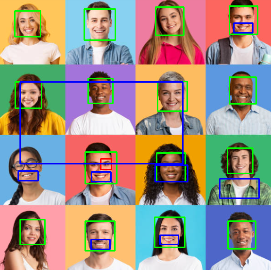

```python
#Detect faces in the image
faces_rect = face_cascade.detectMultiScale(gray_img, scaleFactor=1.1, minNeighbors=3)

for (x, y, w, h) in faces_rect:
    cv2.rectangle(stock_img, (x, y), (x+w, y+h), (0, 255, 0), 2)


for (ex, ey, ew, eh) in eye_cascade.detectMultiScale(gray_img, scaleFactor=1.1, minNeighbors=10):
    cv2.rectangle(stock_img, (ex, ey), (ex+ew, ey+eh), (0, 0, 255), 2)

for (sx, sy, sw, sh) in smile_cascade.detectMultiScale(gray_img, scaleFactor=1.1, minNeighbors=20):
    cv2.rectangle(stock_img, (sx, sy), (sx+sw, sy+sh), (255, 0, 0), 2)

cv2_imshow(stock_img)
```

# Part 2: Optimize Object Detection Performance

To improve our model in 1B, and to make more accurate predictions, it would be wise for us to look for eyes and smiles within the bounding box for faces, meaning, within every face found, we should look for eyes and smiles. We can do this by defining a ROI or Region Of Interest. For the variable, let's call it roi_gray (since it will be applied on the gray_img). The roi_gray crops out the portion of the image that corresponds to the detected face. This cropped region is then used for further detection of eyes and smiles.

Instructions:

- Import the relevant libraries
- Upload the image, and the 3 cascade xml files
- Get the uploaded image and the cascade files
- Read the image and convert it to grayscale
- Load the classifiers into the 3 variables: haar_cascade, eyes_cascade and smile_cascade
- Detect the faces in the image
- The for (x, y, w, h) in faces_rect: loop iterates over each detected face in the image. The coordinates (x, y) and dimensions (w, h) define the top-left corner and the width and height of the bounding box for each face. The cv2.rectangle function draws a green rectangle around the detected face. Now, after applying the cv2.rectangle command, define a variable roi_gray. This variable is equal to the gray_img sliced from y to y+h and x to x+w. (Let me know if you can't figure this out)
- Apply the detectMultiScale method to detect eyes.
- Remember, we are already in a for loop, now start another for loop (nested within the outer loop). This for loop will be exactly similar to the oter loop with different variable for eyes (for faces it was x,y,w and h, use, 4 different variables this time). Apply the cv2.rectangle method
- Similar to the last step, do the same thing for smile detection (another for loop nested within the outer face detection loop). Apply the rectangle method.
- scaleFactor: Explore how adjusting this parameter affects detection accuracy.  
  minNeighbors: Test how different values of minNeighbors impact the number of detected objects and false positives.
- Display the image outside of all loops
- Print how many faces were counted.

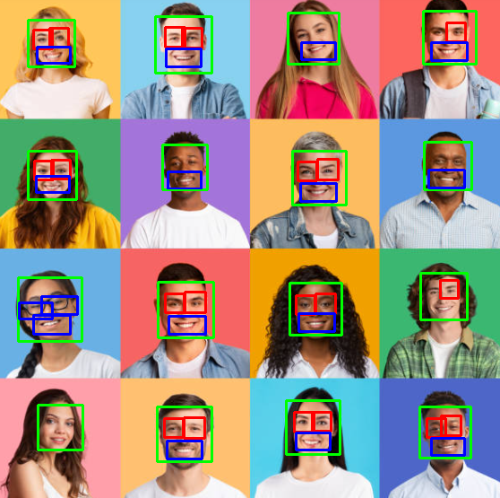

```
Number of faces detected: 16
```

```python
#Read in stock image
stock_img = cv2.imread('Stock_image1.png')
#Convert to
gray_img = cv2.cvtColor(stock_img, cv2.COLOR_BGR2GRAY)
#Detect faces in the image
faces_rect = face_cascade.detectMultiScale(gray_img, scaleFactor=1.091, minNeighbors=3)

for (x, y, w, h) in faces_rect:
    cv2.rectangle(stock_img, (x, y), (x+w, y+h), (0, 255, 0), 2)

    roi_gray = gray_img[y:y+h, x:x+w]
    roi_color = stock_img[y:y+h, x:x+w]

    for (ex, ey, ew, eh) in eye_cascade.detectMultiScale(roi_gray, scaleFactor=1.008, minNeighbors=6):
       cv2.rectangle(roi_color, (ex, ey), (ex+ew, ey+eh), (0, 0, 255), 2)

    for (sx, sy, sw, sh) in smile_cascade.detectMultiScale(roi_gray, scaleFactor=1.01, minNeighbors=10):
      cv2.rectangle(roi_color, (sx, sy), (sx+sw, sy+sh), (255, 0, 0), 2)

cv2_imshow(stock_img)
print(f"Number of faces detected: {len(faces_rect)}")
```

# Part 3: Calculating the Haar value

This task in in the excel sheet provided on Canvas. Solve it there and submit it alongwith this notebook.

# Part 4: Calculating the Integral Image

**Understand the Concept**: The integral image is a data structure that allows you to calculate the sum of pixel values in a rectangular subregion of a 2D matrix efficiently. Each position 𝐼[𝑖,𝑗] in the integral image stores the cumulative sum of all elements in the original matrix from the top-left corner (0,0) to (𝑖,𝑗), inclusive.

1. Define a Python function called compute_integral_image(matrix) that:
- Accepts a 2D list or NumPy array as input.
- Use np.asarray() to ensure the input matrix is a NumPy array.
- Store the dimensions of this array in the variables rows and columns.
- Create a new 2D array, integral_image, of the same shape as the input matrix, initialized to zeros.
- Loop through each position (𝑖,𝑗) in the matrix and calculate the value of the integral image at that position. Follow these rules:
  - Start with equating the value of the current pixels of the integral_image to to the value of the original matrix at (𝑖,𝑗): matrix[i, j]
  - Add the value from the cell directly above (𝑖−1,𝑗) if it exists. (Hint: if i > 0:integral_image[i, j] += integral_image[i - 1, j])
  - Add the value from the cell directly to the left (𝑖,𝑗−1), if it exists.
  - Subtract the value from the overlapping top-left corner (𝑖−1,𝑗−1), if it exists (to avoid double-counting).
- After the loop, return the integral_image.
- Use the provided matrix to test the function and print the output:

```python
# write function here
def compute_integral_image(matrix):
  matrix = np.asarray(matrix)
  rows, columns = matrix.shape
  integral_image = np.zeros((rows, columns), dtype=np.float64)
  for i in range(rows):
    for j in range(columns):
      integral_image[i, j] = matrix[i, j]

      #add value from above if it exists
      if i > 0:
        integral_image[i,j] += integral_image[i-1,j]

      #add value from left if it exists
      if j > 0:
        integral_image[i,j] += integral_image[i,j-1]

      #subtract
      if i > 0 and j > 0:
        integral_image[i,j] -= integral_image[i-1,j-1]

  return integral_image

######

matrix1 = [
    [2, 0, 1, 3],
    [1, 2, 0, 1],
    [3, 1, 2, 0],
    [0, 1, 3, 2]
]
I = compute_integral_image(matrix1)
print(I)

'''
expected output:

[[ 2.  2.  3.  6.]
 [ 3.  5.  6. 10.]
 [ 6.  9. 12. 16.]
 [ 6. 10. 16. 22.]]

'''
```

```
[[ 2.  2.  3.  6.]
 [ 3.  5.  6. 10.]
 [ 6.  9. 12. 16.]
 [ 6. 10. 16. 22.]]
```

```
'\nexpected output:\n\n[[ 2.  2.  3.  6.]\n [ 3.  5.  6. 10.]\n [ 6.  9. 12. 16.]\n [ 6. 10. 16. 22.]]\n\n'
```

# Part 5:

Write a function sum_region(integral_image, x1, y1, x2, y2) that:

- Accepts an integral image and the coordinates of two opposite corners of a rectangle, (x1, y1) (top-left) and (x2, y2) (bottom-right).
- Returns the sum of pixel values in the specified rectangular region using the integral image.
- We will use the integral image that we receive from 5A, the code to text this function is given to you
- Hint: if your answer is not correct, remember to include the correct pixels from the integral image (go through the lesson)

```python
# write function here
def sum_region(integral_image, x1, y1, x2, y2):
  sum = integral_image[x2, y2]
  if x1 > 0:
    sum -= integral_image[x1-1, y2]
  if y1 > 0:
    sum -= integral_image[x2, y1-1]
  if x1 > 0 and y1 > 0:
    sum += integral_image[x1-1, y1-1]
  return sum

######

pixel_sum = sum_region(I,1,1,2,2)
print(pixel_sum)

# expected output = 5
```

```
5.0
```

# Submission Instructions

1. Perform a Restart and Run All by clicking **Tools > Restart session and run all**.
2. Copy the link to your notebook by clicking **Share > Copy Link**.
3. Paste the copied link into the `notebook_url` field in the [Notebook Renderer](https://colab.research.google.com/drive/1CJTipys46ldZxJFwnt7XbdjQUfkmoXeU?usp=sharing) tool and then execute the cell to render the notebook.
4. The Notebook Renderer will open up a save file dialog. Save the resulting HTML file yo your local machine.
5. Submit the HTML file to Canvas.